# Nursing VR Experiences Research

Author

Ivan Widjanarko, Ha Dong Park, Alex Miller, and Professor Kunnen

# **Introduction**

- This project was done in collaboration with the Calvin Nursing Department and Professor Katherine Kunnen
- In our project, nursing students were given a pre-survey (before a nursing simulation experience) and a post-survey (after a nursing simulation experience). In which, they answered questions to test whether confidence levels in health assessments was affected through this virtual reality experience. By exploring the different time points for the nursing virtual reality experience, we tried to find out whether this experience was an effective way to help nursing students become more confident in their fields.
- In this project, we came up with 2 main questions that we explored.
  - How does the different time variables affect student’s confidence for their health assessment?
  - Does previous VR_Experience affect their confidence for the health assessment?

# **Data**

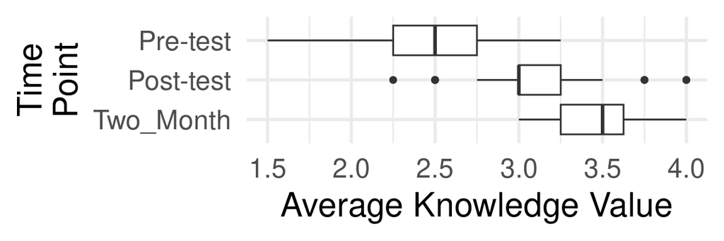

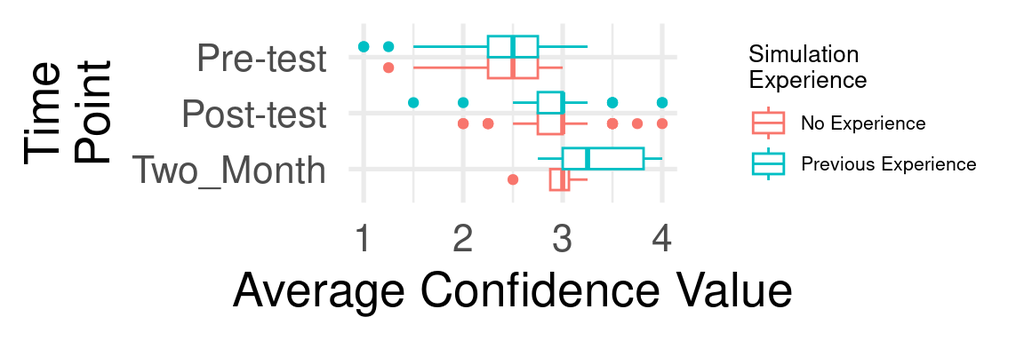

# Statistical Modeling

We’re using two linear regression models for knowledge and confidence in order to explore whether Time Points and Simulation Experiences affect confidence for nurses in health assessments.

# Main Findings

- Our analysis revealed that the timing of health assessments played a role in influencing nurses’ confidence levels, particularly right after using VR, indicating the importance of timing in boosting confidence. While VR experiences could enhance confidence over time, prior simulation experiences didn’t notably contribute to confidence levels, suggesting a focus on assessment timing for confidence improvement.
- Our main findings show that the VR nursing experience overall helped nurses be more confident in health assessments, indicated as they had a higher confidence score right after given the Nursing VR Experience.
- An insight we gained from this model is that students DO NOT need prior experience with VR or simulations to have more confidence in health assessments.

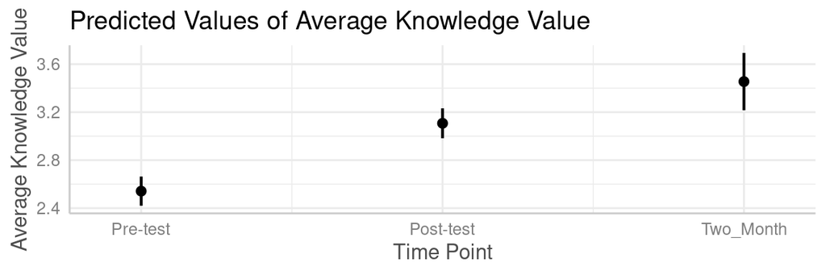

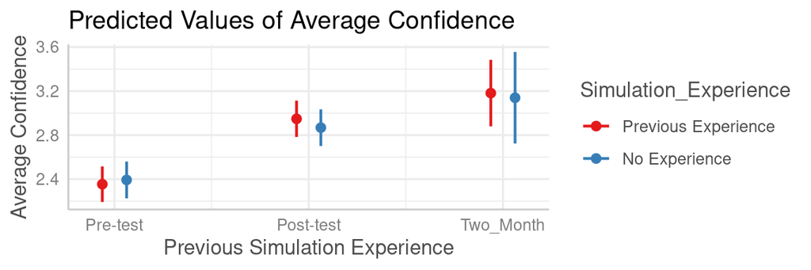

# Our Experience

- Our main challenges included accurately inputting survey data into a spreadsheet, converting and manipulating our data to numerical format, and calculating averages for these datas.
- We faced a challenge in coordinating team meetings due to time constraints, but we successfully resolved it through effective communication.
- Nevertheless, from this experience, we gained knowledge in model and statistical exploration. It was quite overwhelming in the beginning as we did not have a clear plan of execution for the data, however, we were able to overcome this challenge and find beneficial conclusions.

# References & Acknowledgements

- We would like to thank Professor Kunnen for organizing and providing us with the dataset for our project. Her curiosity allowed us the opportunity to explore whether VR goggles and previous simulation experiences had an effect on nurses.
- We also would like to thank Professor DeRuiter for all the help she has given us so far in this dataset. She helped us with our data challenges and explained complex concepts which has been incredibly valuable, and has lead to beneficial results.

# Work-Cited

- “Nursing at Calvin.” Calvin University, calvin.edu/academics/departments-programs/nursing.
- “Katherine Kunnen.” Calvin University, calvin.edu/directory/people/katherine-kunnen.

[figure not shown]